# ADVANCED_AI_07

Session #7- Computer vision with Deep Learning

Advanced AI

[figure not shown]

Prof. Beatriz Blanc

bblanc@faculty.ie.edu

### This session covers:

1. Fine-tune YOLO for a different dataset

```python
import torch
import warnings
warnings.filterwarnings('ignore')
```

### 1. Fine-tune YOLO for a different dataset

What if we wanted the model to detect other classes that are not availabe there  
We could want it to correctly detect foxes vs wolves, for example.

In this case, we'd need to clone the github repo of the model as we will be doing some training, not just inference.

So, let's do it and install the requirements as well. As we will be doing some training this time, it can be that the requirements are different.

Open your terminal, activate the YOLO environment we created previously (`conda activate yolo` - if you are using the Anaconda prompt or the terminal) and, in the folder you would like to have the `yolov5` run the following commands:

```
$ git clone https://github.com/ultralytics/yolov5.git
$ cd yolov5
$ pip install -r requirements.txt
```

If you don't have **git** installed, you should install it first

The **YOLOv5** repository includes several main scripts, but two of the most important ones are `train.py` and `detect.py`. These scripts are fundamental for training and using YOLOv5 models.

#### a) `detect.py`

- **Purpose**: The `detect.py` script is used to apply a trained YOLOv5 model for object detection on images, videos, or live camera feeds. It's useful for inference and showcasing the model's capabilities. We could directly use it for the same purpose as before.
- **Usage**:
  - `detect.py --source` specifies the source for inference, which can be an image, video file, or camera feed.
  - `detect.py --weights` points to the trained YOLOv5 model checkpoint to use for inference.
  - `detect.py --img-size` sets the input image size for inference.
  - `detect.py --conf-thres` sets the confidence threshold for object detection.
  - `detect.py --iou-thres` sets the IoU (Intersection over Union) threshold for non-maximum suppression.
  - `detect.py --device` specifies the device (CPU or GPU) for inference.
- **Explanation**: `detect.py` loads a trained YOLOv5 model and applies it to the specified input source. It detects objects in images or frames of a video stream and can be used for various applications, including autonomous vehicles, surveillance, and more.

So, if we wanted to pass an image for inference using `detect.py`. We would:

```python
!python yolov5/detect.py --weights yolov5s.pt --source detect_1.jpg
```

```
detect: weights=['yolov5s.pt'], source=detect_1.jpg, data=yolov5/data/coco128.yaml, imgsz=[640, 640], conf_thres=0.25, iou_thres=0.45, max_det=1000, device=, view_img=False, save_txt=False, save_format=0, save_csv=False, save_conf=False, save_crop=False, nosave=False, classes=None, agnostic_nms=Fals…
fatal: cannot change to '/Users/beatrizblanc/Documents/01': No such file or directory
YOLOv5 🚀 2025-9-29 Python-3.10.18 torch-2.8.0 CPU

Fusing layers...
YOLOv5s summary: 213 layers, 7225885 parameters, 0 gradients, 16.4 GFLOPs
image 1/1 /Users/beatrizblanc/Documents/01 Work/04 Teaching/02 IE/02 clases/03 Computer vision/session_7/detect_1.jpg: 384x640 6 persons, 1 bicycle, 1 car, 2 buss, 1 traffic light, 39.9ms
Speed: 0.3ms pre-process, 39.9ms inference, 0.6ms NMS per image at shape (1, 3, 640, 640)
Results saved to yolov5/runs/detect/exp2
```

[figure not shown]

```python
from IPython.display import Image, display

display(Image(filename='yolov5/runs/detect/exp2/detect_1.jpg'))
```

**YOLOv5 inference is deterministic** — the differences we may see between both inferences are due to pre/post-processing differences between the `detect.py` script and the Torch Hub wrapper.

#### b) `train.py`

- **Purpose**: The `train.py` script is used to train a YOLOv5 model on a custom dataset. It's a crucial component for fine-tuning or creating our own object detection models.
- **Usage**:
  - `train.py --img-size` specifies the input image size for training.
  - `train.py --batch-size` sets the batch size for training.
  - `train.py --epochs` determines the number of training epochs.
  - `train.py --data` specifies the path to the data.yaml configuration file containing dataset information.
  - `train.py --weights` allows to start training from a pre-trained YOLOv5 model checkpoint.
  - `train.py --cfg` specifies the YOLOv5 model configuration file to use.
  - `train.py --name` sets a name for the training experiment.
  - `train.py --project` specifies the project name for logging.
- **Explanation**: `train.py` takes care of loading the dataset, initializing the YOLOv5 model architecture, and performing the training loop. It updates the model's weights to minimize the detection loss, making it suitable for custom object detection tasks.

These two main scripts, `train.py` and `detect.py`, form the core of YOLOv5's capabilities, allowing to both train custom models and apply them for object detection tasks. Understanding these scripts is essential for anyone studying computer vision and deep learning.

So, we are going to use a set of images with **foxes** and **wolves** to see if it can learn to recognize these.

Our dataset has already the right YOLO format as we specific it like that when downloading the data:  
`<class_id> <x_center> <y_center> <width> <height>`

We can go to [**Roboflow**](https://app.roboflow.com/advancedai-bfw35) to get the data, a platform that provides tools for dataset creation, data annotation, model training, and model deployment.

In your case, you don't need to go there to get it, you can download the folders from the *blackboard*

The **annotation** (information regarding the class, bounding boxes, etc.) has already been extracted using the YOLO format.

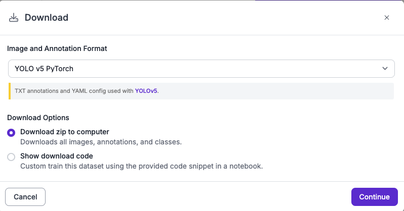

```python
!python yolov5/train.py \
    --img 640 \
    --batch 16 \
    --epochs 10 \
    --data fox_and_wolves/data.yaml \
    --weights yolov5s.pt \
    --cache --device mps
```

```
train: weights=yolov5s.pt, cfg=, data=fox_and_wolves/data.yaml, hyp=yolov5/data/hyps/hyp.scratch-low.yaml, epochs=10, batch_size=16, imgsz=640, rect=False, resume=False, nosave=False, noval=False, noautoanchor=False, noplots=False, evolve=None, evolve_population=yolov5/data/hyps, resume_evolve=None,…
github: up to date with https://github.com/ultralytics/yolov5 ✅
fatal: cannot change to '/Users/beatrizblanc/Documents/01': No such file or directory
YOLOv5 🚀 2025-9-29 Python-3.10.18 torch-2.8.0 MPS

hyperparameters: lr0=0.01, lrf=0.01, momentum=0.937, weight_decay=0.0005, warmup_epochs=3.0, warmup_momentum=0.8, warmup_bias_lr=0.1, box=0.05, cls=0.5, cls_pw=1.0, obj=1.0, obj_pw=1.0, iou_t=0.2, anchor_t=4.0, fl_gamma=0.0, hsv_h=0.015, hsv_s=0.7, hsv_v=0.4, degrees=0.0, translate=0.1, scale=0.5, s…
Comet: run 'pip install comet_ml' to automatically track and visualize YOLOv5 🚀 runs in Comet
TensorBoard: Start with 'tensorboard --logdir yolov5/runs/train', view at http://localhost:6006/
Overriding model.yaml nc=80 with nc=2

                 from  n    params  module                                  arguments
  0                -1  1      3520  models.common.Conv                      [3, 32, 6, 2, 2]
  1                -1  1     18560  models.common.Conv                      [32, 64, 3, 2]
  2                -1  1     18816  models.common.C3                        [64, 64, 1]
  3                -1  1     73984  models.common.Conv                      [64, 128, 3, 2]
  4                -1  2    115712  models.common.C3                        [128, 128, 2]
  5                -1  1    295424  models.common.Conv                      [128, 256, 3, 2]
  6                -1  3    625152  models.common.C3                        [256, 256, 3]
  7                -1  1   1180672  models.common.Conv                      [256, 512, 3, 2]
  8                -1  1   1182720  models.common.C3                        [512, 512, 1]
  9                -1  1    656896  models.common.SPPF                      [512, 512, 5]
 10                -1  1    131584  models.common.Conv                      [512, 256, 1, 1]
 11                -1  1         0  torch.nn.modules.upsampling.Upsample    [None, 2, 'nearest']
 12           [-1, 6]  1         0  models.common.Concat                    [1]
 13                -1  1    361984  models.common.C3                        [512, 256, 1, False]
 14                -1  1     33024  models.common.Conv                      [256, 128, 1, 1]
 15                -1  1         0  torch.nn.modules.upsampling.Upsample    [None, 2, 'nearest']
 16           [-1, 4]  1         0  models.common.Concat                    [1]
 17                -1  1     90880  models.common.C3                        [256, 128, 1, False]
 18                -1  1    147712  models.common.Conv                      [128, 128, 3, 2]
 19          [-1, 14]  1         0  models.common.Concat                    [1]
 20                -1  1    296448  models.common.C3                        [256, 256, 1, False]
 21                -1  1    590336  models.common.Conv                      [256, 256, 3, 2]
 22          [-1, 10]  1         0  models.common.Concat                    [1]
 23                -1  1   1182720  models.common.C3                        [512, 512, 1, False]
 24      [17, 20, 23]  1     18879  models.yolo.Detect                      [2, [[10, 13, 16, 30, 33, 23], [30, 61, 62, 45, 59, 119], [116, 90, 156, 198, 373, 326]], [128, 256, 512]]
Model summary: 214 layers, 7025023 parameters, 7025023 gradients, 16.0 GFLOPs

Transferred 343/349 items from yolov5s.pt
optimizer: SGD(lr=0.01) with parameter groups 57 weight(decay=0.0), 60 weight(decay=0.0005), 60 bias
```

[output cut: 370 more lines]

```
                 Class     Images  Instances          P          R      mAP50
                   all         46         53      0.499      0.793      0.595      0.398

10 epochs completed in 0.050 hours.
Optimizer stripped from yolov5/runs/train/exp/weights/last.pt, 14.4MB
Optimizer stripped from yolov5/runs/train/exp/weights/best.pt, 14.4MB

Validating yolov5/runs/train/exp/weights/best.pt...
Fusing layers...
Model summary: 157 layers, 7015519 parameters, 0 gradients, 15.8 GFLOPs
                 Class     Images  Instances          P          R      mAP50
                   all         46         53      0.498      0.792      0.599      0.399
                  Wolf         46         30      0.456      0.671      0.497       0.33
                   fox         46         23       0.54      0.913      0.702      0.468
Results saved to yolov5/runs/train/exp
```

Let's check how well it does with images from the test dataset:

```python
!python yolov5/detect.py --weights yolov5/runs/train/exp/weights/best.pt --source fox_and_wolves/test/images/
```

```
detect: weights=['yolov5/runs/train/exp/weights/best.pt'], source=fox_and_wolves/test/images/, data=yolov5/data/coco128.yaml, imgsz=[640, 640], conf_thres=0.25, iou_thres=0.45, max_det=1000, device=, view_img=False, save_txt=False, save_format=0, save_csv=False, save_conf=False, save_crop=False, nos…
fatal: cannot change to '/Users/beatrizblanc/Documents/01': No such file or directory
YOLOv5 🚀 2025-9-29 Python-3.10.18 torch-2.8.0 CPU

Fusing layers...
Model summary: 157 layers, 7015519 parameters, 0 gradients, 15.8 GFLOPs
image 1/31 /Users/beatrizblanc/Documents/01 Work/04 Teaching/02 IE/02 clases/03 Computer vision/session_7/fox_and_wolves/test/images/1576008278152_jpeg.rf.5b8feefab0cf31bc6a2a30d3f43c79cd.jpg: 384x640 1 Wolf, 33.8ms
image 2/31 /Users/beatrizblanc/Documents/01 Work/04 Teaching/02 IE/02 clases/03 Computer vision/session_7/fox_and_wolves/test/images/190307-grey-wolves_jpg.rf.88ab046176872ed7361c36a631d45aad.jpg: 448x640 1 Wolf, 37.8ms
image 3/31 /Users/beatrizblanc/Documents/01 Work/04 Teaching/02 IE/02 clases/03 Computer vision/session_7/fox_and_wolves/test/images/82a48db4-d0a2-431c-bfa0-db97b2da2f32_jpg.rf.96c37037b33cdadb8c1a08ad252ad1f7.jpg: 448x640 1 Wolf, 1 fox, 37.0ms
image 4/31 /Users/beatrizblanc/Documents/01 Work/04 Teaching/02 IE/02 clases/03 Computer vision/session_7/fox_and_wolves/test/images/Eurasian_wolfJPG_jpg.rf.7acbe7228c06eff0affb046222103e3c.jpg: 448x640 1 Wolf, 1 fox, 35.8ms
image 5/31 /Users/beatrizblanc/Documents/01 Work/04 Teaching/02 IE/02 clases/03 Computer vision/session_7/fox_and_wolves/test/images/Fox-Study-4_jpg.rf.e761450edfbfc741d940f365f8c1d592.jpg: 640x448 1 Wolf, 36.9ms
image 6/31 /Users/beatrizblanc/Documents/01 Work/04 Teaching/02 IE/02 clases/03 Computer vision/session_7/fox_and_wolves/test/images/Fox11_jpg.rf.6e0113b52c048f1f81bf7dc7d0795191.jpg: 480x640 1 Wolf, 1 fox, 41.3ms
image 7/31 /Users/beatrizblanc/Documents/01 Work/04 Teaching/02 IE/02 clases/03 Computer vision/session_7/fox_and_wolves/test/images/Fox16_jpeg.rf.d4b55aeb0eb6c972ce638b031126ee61.jpg: 448x640 1 Wolf, 1 fox, 36.9ms
image 8/31 /Users/beatrizblanc/Documents/01 Work/04 Teaching/02 IE/02 clases/03 Computer vision/session_7/fox_and_wolves/test/images/Fox31_jpg.rf.41655be6f943b293e80bd1bdcf2fad65.jpg: 384x640 1 Wolf, 34.2ms
image 9/31 /Users/beatrizblanc/Documents/01 Work/04 Teaching/02 IE/02 clases/03 Computer vision/session_7/fox_and_wolves/test/images/Fox35_jpg.rf.cc12bc8ceca25a5d867714c9797e2b14.jpg: 448x640 (no detections), 39.5ms
image 10/31 /Users/beatrizblanc/Documents/01 Work/04 Teaching/02 IE/02 clases/03 Computer vision/session_7/fox_and_wolves/test/images/Fox40_jpg.rf.7bc18d049f5636df7ecff1693164e6ba.jpg: 640x640 1 Wolf, 59.5ms
image 11/31 /Users/beatrizblanc/Documents/01 Work/04 Teaching/02 IE/02 clases/03 Computer vision/session_7/fox_and_wolves/test/images/Fox42_jpg.rf.c15f3d24a8158d6dac7e8998ff342505.jpg: 448x640 (no detections), 39.3ms
image 12/31 /Users/beatrizblanc/Documents/01 Work/04 Teaching/02 IE/02 clases/03 Computer vision/session_7/fox_and_wolves/test/images/Img-10159_jpg.rf.b63d56d1a3b323937a07bceae8cd2d38.jpg: 640x608 1 Wolf, 1 fox, 52.4ms
image 13/31 /Users/beatrizblanc/Documents/01 Work/04 Teaching/02 IE/02 clases/03 Computer vision/session_7/fox_and_wolves/test/images/Img-11432_jpg.rf.a67935cb79e1aaf9fe85c08837b80fab.jpg: 448x640 (no detections), 38.7ms
image 14/31 /Users/beatrizblanc/Documents/01 Work/04 Teaching/02 IE/02 clases/03 Computer vision/session_7/fox_and_wolves/test/images/Img-11443_jpg.rf.d57dfe22ede061983eefb46366c3574a.jpg: 448x640 (no detections), 36.3ms
image 15/31 /Users/beatrizblanc/Documents/01 Work/04 Teaching/02 IE/02 clases/03 Computer vision/session_7/fox_and_wolves/test/images/Img-11595_jpg.rf.d89272703546da9cce542a1d428060c5.jpg: 544x640 (no detections), 45.0ms
image 16/31 /Users/beatrizblanc/Documents/01 Work/04 Teaching/02 IE/02 clases/03 Computer vision/session_7/fox_and_wolves/test/images/Img-11683_jpg.rf.96c3f23b6492aad346cabe240ca1f9ce.jpg: 448x640 1 Wolf, 1 fox, 36.5ms
image 17/31 /Users/beatrizblanc/Documents/01 Work/04 Teaching/02 IE/02 clases/03 Computer vision/session_7/fox_and_wolves/test/images/Img-11929_jpg.rf.d5da17d0316b9ac06d0fe0f6931c5afd.jpg: 448x640 1 Wolf, 36.2ms
image 18/31 /Users/beatrizblanc/Documents/01 Work/04 Teaching/02 IE/02 clases/03 Computer vision/session_7/fox_and_wolves/test/images/Img-12229_jpg.rf.72bd76742d9ba34fba599bffa3c0a0a0.jpg: 480x640 (no detections), 39.1ms
image 19/31 /Users/beatrizblanc/Documents/01 Work/04 Teaching/02 IE/02 clases/03 Computer vision/session_7/fox_and_wolves/test/images/Img-12467_jpg.rf.8e5b3035ac9dd87a2b9072ca341491c8.jpg: 448x640 1 Wolf, 37.3ms
image 20/31 /Users/beatrizblanc/Documents/01 Work/04 Teaching/02 IE/02 clases/03 Computer vision/session_7/fox_and_wolves/test/images/National-Geographic-Your-Shot_jpg.rf.b36e76b062eeb06a8baa6596efdded21.jpg: 640x416 (no detections), 34.9ms
```

[output cut: 13 more lines]

If we take a look at the images after the detection, we can see that some of them have 2 boxes, each predicting 1 class.

Because wolves and foxes are visually similar (shape, pose, environment, etc.) the model may give high confidence scores for both classes in the same region.

For a given object, you might see something like:

| Box | Objectness | Fox score | Wolf score |
| --- | --- | --- | --- |
| A | 0.9 | 0.85 | 0.75 |

YOLOv5 then reports the highest class score per box by default, but it might still generate separate overlapping boxes for two classes if both are confident and survive non-max suppression (NMS).

YOLOv5 uses class-aware NMS by default, meaning:

- It suppresses overlapping boxes within the same class.
- But it does not suppress overlapping boxes of different classes. So, if the model predicts:
  - Box A (fox, 0.85)
  - Box B (wolve, 0.75)

and they overlap heavily, both will remain, because NMS only removes duplicates of the same class

We could fix this using:

```
!python yolov5/detect.py --weights yolov5/runs/train/exp/weights/best.pt --source fox_and_wolves/test/images/ --agnostic-nms
```

This makes NMS *class-agnostic*, meaning that if two boxes overlap a lot, only the highest-confidence one remains, regardless of class.

```python
!python yolov5/detect.py --weights yolov5/runs/train/exp/weights/best.pt --source fox_and_wolves/test/images/ --agnostic-nms
```

```
detect: weights=['yolov5/runs/train/exp/weights/best.pt'], source=fox_and_wolves/test/images/, data=yolov5/data/coco128.yaml, imgsz=[640, 640], conf_thres=0.25, iou_thres=0.45, max_det=1000, device=, view_img=False, save_txt=False, save_format=0, save_csv=False, save_conf=False, save_crop=False, nos…
fatal: cannot change to '/Users/beatrizblanc/Documents/01': No such file or directory
YOLOv5 🚀 2025-9-29 Python-3.10.18 torch-2.8.0 CPU

Fusing layers...
Model summary: 157 layers, 7015519 parameters, 0 gradients, 15.8 GFLOPs
image 1/31 /Users/beatrizblanc/Documents/01 Work/04 Teaching/02 IE/02 clases/03 Computer vision/session_7/fox_and_wolves/test/images/1576008278152_jpeg.rf.5b8feefab0cf31bc6a2a30d3f43c79cd.jpg: 384x640 1 Wolf, 37.0ms
image 2/31 /Users/beatrizblanc/Documents/01 Work/04 Teaching/02 IE/02 clases/03 Computer vision/session_7/fox_and_wolves/test/images/190307-grey-wolves_jpg.rf.88ab046176872ed7361c36a631d45aad.jpg: 448x640 1 Wolf, 41.1ms
image 3/31 /Users/beatrizblanc/Documents/01 Work/04 Teaching/02 IE/02 clases/03 Computer vision/session_7/fox_and_wolves/test/images/82a48db4-d0a2-431c-bfa0-db97b2da2f32_jpg.rf.96c37037b33cdadb8c1a08ad252ad1f7.jpg: 448x640 1 fox, 38.8ms
image 4/31 /Users/beatrizblanc/Documents/01 Work/04 Teaching/02 IE/02 clases/03 Computer vision/session_7/fox_and_wolves/test/images/Eurasian_wolfJPG_jpg.rf.7acbe7228c06eff0affb046222103e3c.jpg: 448x640 1 Wolf, 38.9ms
image 5/31 /Users/beatrizblanc/Documents/01 Work/04 Teaching/02 IE/02 clases/03 Computer vision/session_7/fox_and_wolves/test/images/Fox-Study-4_jpg.rf.e761450edfbfc741d940f365f8c1d592.jpg: 640x448 1 Wolf, 41.1ms
image 6/31 /Users/beatrizblanc/Documents/01 Work/04 Teaching/02 IE/02 clases/03 Computer vision/session_7/fox_and_wolves/test/images/Fox11_jpg.rf.6e0113b52c048f1f81bf7dc7d0795191.jpg: 480x640 1 Wolf, 43.9ms
image 7/31 /Users/beatrizblanc/Documents/01 Work/04 Teaching/02 IE/02 clases/03 Computer vision/session_7/fox_and_wolves/test/images/Fox16_jpeg.rf.d4b55aeb0eb6c972ce638b031126ee61.jpg: 448x640 1 Wolf, 39.7ms
image 8/31 /Users/beatrizblanc/Documents/01 Work/04 Teaching/02 IE/02 clases/03 Computer vision/session_7/fox_and_wolves/test/images/Fox31_jpg.rf.41655be6f943b293e80bd1bdcf2fad65.jpg: 384x640 1 Wolf, 35.9ms
image 9/31 /Users/beatrizblanc/Documents/01 Work/04 Teaching/02 IE/02 clases/03 Computer vision/session_7/fox_and_wolves/test/images/Fox35_jpg.rf.cc12bc8ceca25a5d867714c9797e2b14.jpg: 448x640 (no detections), 39.2ms
image 10/31 /Users/beatrizblanc/Documents/01 Work/04 Teaching/02 IE/02 clases/03 Computer vision/session_7/fox_and_wolves/test/images/Fox40_jpg.rf.7bc18d049f5636df7ecff1693164e6ba.jpg: 640x640 1 Wolf, 58.2ms
image 11/31 /Users/beatrizblanc/Documents/01 Work/04 Teaching/02 IE/02 clases/03 Computer vision/session_7/fox_and_wolves/test/images/Fox42_jpg.rf.c15f3d24a8158d6dac7e8998ff342505.jpg: 448x640 (no detections), 38.4ms
image 12/31 /Users/beatrizblanc/Documents/01 Work/04 Teaching/02 IE/02 clases/03 Computer vision/session_7/fox_and_wolves/test/images/Img-10159_jpg.rf.b63d56d1a3b323937a07bceae8cd2d38.jpg: 640x608 1 Wolf, 51.0ms
image 13/31 /Users/beatrizblanc/Documents/01 Work/04 Teaching/02 IE/02 clases/03 Computer vision/session_7/fox_and_wolves/test/images/Img-11432_jpg.rf.a67935cb79e1aaf9fe85c08837b80fab.jpg: 448x640 (no detections), 37.2ms
image 14/31 /Users/beatrizblanc/Documents/01 Work/04 Teaching/02 IE/02 clases/03 Computer vision/session_7/fox_and_wolves/test/images/Img-11443_jpg.rf.d57dfe22ede061983eefb46366c3574a.jpg: 448x640 (no detections), 38.9ms
image 15/31 /Users/beatrizblanc/Documents/01 Work/04 Teaching/02 IE/02 clases/03 Computer vision/session_7/fox_and_wolves/test/images/Img-11595_jpg.rf.d89272703546da9cce542a1d428060c5.jpg: 544x640 (no detections), 48.9ms
image 16/31 /Users/beatrizblanc/Documents/01 Work/04 Teaching/02 IE/02 clases/03 Computer vision/session_7/fox_and_wolves/test/images/Img-11683_jpg.rf.96c3f23b6492aad346cabe240ca1f9ce.jpg: 448x640 1 Wolf, 40.1ms
image 17/31 /Users/beatrizblanc/Documents/01 Work/04 Teaching/02 IE/02 clases/03 Computer vision/session_7/fox_and_wolves/test/images/Img-11929_jpg.rf.d5da17d0316b9ac06d0fe0f6931c5afd.jpg: 448x640 1 Wolf, 40.0ms
image 18/31 /Users/beatrizblanc/Documents/01 Work/04 Teaching/02 IE/02 clases/03 Computer vision/session_7/fox_and_wolves/test/images/Img-12229_jpg.rf.72bd76742d9ba34fba599bffa3c0a0a0.jpg: 480x640 (no detections), 42.2ms
image 19/31 /Users/beatrizblanc/Documents/01 Work/04 Teaching/02 IE/02 clases/03 Computer vision/session_7/fox_and_wolves/test/images/Img-12467_jpg.rf.8e5b3035ac9dd87a2b9072ca341491c8.jpg: 448x640 1 Wolf, 39.4ms
image 20/31 /Users/beatrizblanc/Documents/01 Work/04 Teaching/02 IE/02 clases/03 Computer vision/session_7/fox_and_wolves/test/images/National-Geographic-Your-Shot_jpg.rf.b36e76b062eeb06a8baa6596efdded21.jpg: 640x416 (no detections), 35.6ms
```

[output cut: 13 more lines]

Now it looks a bit better, right?

Although there are some wrong, and for some we don't even have a label...

That's because our model was not so certain, and if the confidence is <0.25, it won't show the class.  
We could lower this threshold if we'd like a class anyway:

```
python detect.py --conf-thres 0.1 ...
```

### How do we evaluate our fine-tunning?

YOLOv5 automatically computes common object detection metrics when you run `val.py` or use the `--val` flag during training. The key metrics are:

| Metric | What it measures | Typical Good Values |
| --- | --- | --- |
| **Precision** | How many predicted boxes are correct | ≥ 0.8 is usually decent |
| **Recall** | How many ground-truth boxes were found | ≥ 0.7 is often a good sign |
| **mAP@0.5** | Mean Average Precision at IoU 0.5 | > 0.8 means strong performance |
| **mAP@0.5:0.95** | Average mAP across IoU thresholds (0.5–0.95) | This is stricter; > 0.5 is solid |

```python
!python yolov5/val.py --weights yolov5/runs/train/exp/weights/best.pt --data fox_and_wolves/data.yaml --task test
```

```
val: data=fox_and_wolves/data.yaml, weights=['yolov5/runs/train/exp/weights/best.pt'], batch_size=32, imgsz=640, conf_thres=0.001, iou_thres=0.6, max_det=300, task=test, device=, workers=8, single_cls=False, augment=False, verbose=False, save_txt=False, save_hybrid=False, save_conf=False, save_json=…
fatal: cannot change to '/Users/beatrizblanc/Documents/01': No such file or directory
YOLOv5 🚀 2025-9-29 Python-3.10.18 torch-2.8.0 CPU

Fusing layers...
Model summary: 157 layers, 7015519 parameters, 0 gradients, 15.8 GFLOPs
test: Scanning /Users/beatrizblanc/Documents/01 Work/04 Teaching/02 IE/02 clases
test: New cache created: /Users/beatrizblanc/Documents/01 Work/04 Teaching/02 IE/02 clases/03 Computer vision/session_7/fox_and_wolves/test/labels.cache
                 Class     Images  Instances          P          R      mAP50
                   all         31         35      0.484      0.723      0.591      0.379
                  Wolf         31         24      0.633      0.719      0.692      0.467
                   fox         31         11      0.336      0.727       0.49      0.291
Speed: 0.5ms pre-process, 204.9ms inference, 0.5ms NMS per image at shape (32, 3, 640, 640)
Results saved to yolov5/runs/val/exp
```

We can also look at the confusion matrix in `runs/val/exp/confusion_matrix.png`

So, our model doesn't do so good...

What could we do to improve the results?

- Add more diverse training images — different poses, lighting, distances, seasons, etc.
- Include hard negatives (images with no foxes or wolves) so the model learns when not to predict anything.
- Check for mislabelled or inaccurate bounding boxes (common source of noisy predictions).
- Increase the number of epochs

We can also do some visual inspection, as we did before.

If speed or model size is important for the use case, we should also check it:

- Inference time per image / FPS
- GPU/CPU usage
- Model size (.pt file size)

Or use the confusion matrix also generated

### Multi-class fine-tuning YOLO for better performance

If we wanted our model to detect both COCO classes and foxes and wolves (new classes), we'd need to do a multi-class fine-tunning

For this, we'd need to have some COCO data as well, or some images with all those classes, plus some images with foxes and wolves

In this case it would be pretty important that, if we don't want to miss the performance on the existing COCO classes, that both our training dataset and validation datasets are well balanced.

The training process would be the same

```
!python yolov5/train.py \
    --img 640 \
    --batch 16 \
    --epochs 3 \
    --data fox_and_wolves_and_COCO/data.yaml \
    --weights yolov5s.pt \
    --cache
```

Or we could also freeze some layers

```
!python yolov5/train.py --data fox_and_COCO/data.yaml --weights yolov5s.pt --epochs 15 --freeze 10 --device mps
# freezing the backbone (feature extractor) layers so the model only learns the detection head
```